```r
#load data
library(lmtest)
library(leaps)
library(Stat2Data)
bk.data <- read.csv(file = "~/SC321/Reports/Report 4/birdkeeping.csv")
attach(bk.data)
bk.df <- data.frame(bk.data)
print(bk.df)
```

```
##             LC    SEX   SS     BK AG YR CD
## 1   LUNGCANCER   MALE  LOW   BIRD 37 19 12
## 2   LUNGCANCER   MALE  LOW   BIRD 41 22 15
## 3   LUNGCANCER   MALE HIGH NOBIRD 43 19 15
## 4   LUNGCANCER   MALE  LOW   BIRD 46 24 15
## 5   LUNGCANCER   MALE  LOW   BIRD 49 31 20
## 6   LUNGCANCER   MALE HIGH NOBIRD 51 24 15
## 7   LUNGCANCER   MALE HIGH   BIRD 52 31 20
## 8   LUNGCANCER   MALE  LOW NOBIRD 53 33 20
## 9   LUNGCANCER   MALE  LOW   BIRD 56 33 10
## 10  LUNGCANCER   MALE HIGH NOBIRD 56 26 25
## 11  LUNGCANCER   MALE  LOW NOBIRD 56 35 40
## 12  LUNGCANCER   MALE  LOW NOBIRD 56 36 25
## 13  LUNGCANCER   MALE  LOW   BIRD 56 36 20
## 14  LUNGCANCER   MALE  LOW   BIRD 57 39 25
```

[output cut: 133 more lines]

```r
#creating table to see how many have lung cancer and are bird keepers
my.table <- table(bk.df$BK, bk.df$LC)
my.table
```

```
##
##          LUNGCANCER NOCANCER
##   BIRD           33       34
##   NOBIRD         16       64
```

observations:

What are the odds of having a bird? 67/80 What are the odds of having a bird if you have lung cancer? 33/16 What are the odds of having a bird if you don’t have lung cancer? 34/64 What are the odds ratio for having a bird comparing those who have and don’t have lung cancer? (33/16)/(34/64)

```r
#do the math
yesbird <- 67/80
birdcancer <- 33/16
birdnocancer <- 34/64
oddsRatio <- (33/34)/(16/64)
yesbird
```

```
## [1] 0.8375
```

```r
birdcancer
```

```
## [1] 2.0625
```

```r
birdnocancer
```

```
## [1] 0.53125
```

```r
oddsRatio
```

```
## [1] 3.882353
```

This means that those who have lung cancer are 3.88 times more likely to have a bird than those who do not have lung cancer.

Linear models

```r
bk.df$LC_ind <- as.numeric(bk.df$LC == "LUNGCANCER")
bk.df$BK_ind <- as.numeric(bk.df$BK == "BIRD")
main.glm <- glm(bk.df$LC_ind ~ bk.df$BK_ind + as.factor(bk.df$SEX) + as.factor(bk.df$SS) + bk.df$AG + bk.df$YR + bk.df$CD, family="binomial")
#str(bk.df)
summary(main.glm)
```

```
##
## Call:
## glm(formula = bk.df$LC_ind ~ bk.df$BK_ind + as.factor(bk.df$SEX) +
##     as.factor(bk.df$SS) + bk.df$AG + bk.df$YR + bk.df$CD, family = "binomial")
##
## Deviance Residuals:
##     Min       1Q   Median       3Q      Max
## -1.5642  -0.8333  -0.4605   0.9808   2.2460
##
## Coefficients:
##                          Estimate Std. Error z value Pr(>|z|)
## (Intercept)              -1.27064    1.82531  -0.696 0.486351
## bk.df$BK_ind              1.36259    0.41128   3.313 0.000923 ***
## as.factor(bk.df$SEX)MALE -0.56127    0.53116  -1.057 0.290653
## as.factor(bk.df$SS)LOW   -0.10545    0.46885  -0.225 0.822050
## bk.df$AG                 -0.03976    0.03548  -1.120 0.262503
## bk.df$YR                  0.07287    0.02649   2.751 0.005940 **
## bk.df$CD                  0.02602    0.02552   1.019 0.308055
## ---
## Signif. codes:  0 '***' 0.001 '**' 0.01 '*' 0.05 '.' 0.1 ' ' 1
##
## (Dispersion parameter for binomial family taken to be 1)
##
##     Null deviance: 187.14  on 146  degrees of freedom
## Residual deviance: 154.20  on 140  degrees of freedom
## AIC: 168.2
##
## Number of Fisher Scoring iterations: 5
```

```r
step(main.glm)
```

```
## Start:  AIC=168.2
## bk.df$LC_ind ~ bk.df$BK_ind + as.factor(bk.df$SEX) + as.factor(bk.df$SS) +
##     bk.df$AG + bk.df$YR + bk.df$CD
##
##                        Df Deviance    AIC
## - as.factor(bk.df$SS)   1   154.25 166.25
## - bk.df$CD              1   155.24 167.24
## - as.factor(bk.df$SEX)  1   155.32 167.32
## - bk.df$AG              1   155.49 167.49
## <none>                      154.20 168.20
## - bk.df$YR              1   163.93 175.93
## - bk.df$BK_ind          1   165.87 177.87
##
## Step:  AIC=166.25
## bk.df$LC_ind ~ bk.df$BK_ind + as.factor(bk.df$SEX) + bk.df$AG +
##     bk.df$YR + bk.df$CD
##
##                        Df Deviance    AIC
## - as.factor(bk.df$SEX)  1   155.32 165.32
## - bk.df$CD              1   155.32 165.32
## - bk.df$AG              1   155.50 165.50
## <none>                      154.25 166.25
## - bk.df$YR              1   164.09 174.09
## - bk.df$BK_ind          1   165.90 175.90
##
## Step:  AIC=165.32
## bk.df$LC_ind ~ bk.df$BK_ind + bk.df$AG + bk.df$YR + bk.df$CD
##
##                Df Deviance    AIC
## - bk.df$CD      1   156.22 164.22
## - bk.df$AG      1   156.75 164.75
## <none>              155.32 165.32
## - bk.df$YR      1   164.18 172.18
## - bk.df$BK_ind  1   168.35 176.35
##
## Step:  AIC=164.22
## bk.df$LC_ind ~ bk.df$BK_ind + bk.df$AG + bk.df$YR
##
##                Df Deviance    AIC
## - bk.df$AG      1   158.11 164.11
## <none>              156.22 164.22
## - bk.df$BK_ind  1   168.83 174.83
## - bk.df$YR      1   172.53 178.53
##
## Step:  AIC=164.11
## bk.df$LC_ind ~ bk.df$BK_ind + bk.df$YR
##
##                Df Deviance    AIC
## <none>              158.11 164.11
## - bk.df$YR      1   172.93 176.93
## - bk.df$BK_ind  1   173.17 177.17
```

```
##
## Call:  glm(formula = bk.df$LC_ind ~ bk.df$BK_ind + bk.df$YR, family = "binomial")
##
## Coefficients:
##  (Intercept)  bk.df$BK_ind      bk.df$YR
##     -3.18016       1.47555       0.05825
##
## Degrees of Freedom: 146 Total (i.e. Null);  144 Residual
## Null Deviance:       187.1
## Residual Deviance: 158.1     AIC: 164.1
```

```r
fitMain.glm <- glm(bk.df$LC_ind ~ bk.df$BK_ind + bk.df$YR, family="binomial")
#str(bk.df)
summary(fitMain.glm)
```

```
##
## Call:
## glm(formula = bk.df$LC_ind ~ bk.df$BK_ind + bk.df$YR, family = "binomial")
##
## Deviance Residuals:
##     Min       1Q   Median       3Q      Max
## -1.6093  -0.8644  -0.5283   0.9479   2.0937
##
## Coefficients:
##              Estimate Std. Error z value Pr(>|z|)
## (Intercept)  -3.18016    0.63640  -4.997 5.82e-07 ***
## bk.df$BK_ind  1.47555    0.39588   3.727 0.000194 ***
## bk.df$YR      0.05825    0.01685   3.458 0.000544 ***
## ---
## Signif. codes:  0 '***' 0.001 '**' 0.01 '*' 0.05 '.' 0.1 ' ' 1
##
## (Dispersion parameter for binomial family taken to be 1)
##
##     Null deviance: 187.14  on 146  degrees of freedom
## Residual deviance: 158.11  on 144  degrees of freedom
## AIC: 164.11
##
## Number of Fisher Scoring iterations: 4
```

```r
lrtest(main.glm, fitMain.glm)
```

```
## Likelihood ratio test
##
## Model 1: bk.df$LC_ind ~ bk.df$BK_ind + as.factor(bk.df$SEX) + as.factor(bk.df$SS) +
##     bk.df$AG + bk.df$YR + bk.df$CD
## Model 2: bk.df$LC_ind ~ bk.df$BK_ind + bk.df$YR
##   #Df  LogLik Df Chisq Pr(>Chisq)
## 1   7 -77.099
## 2   3 -79.057 -4 3.916     0.4175
```

Since this p-value is not less than .05, we will fail to reject the null hypothesis.

This means the model and the fitModel fit the data equally well. Thus, we should use the fitModel because the additional predictor variables in the first model don’t offer a significant improvement in fit.

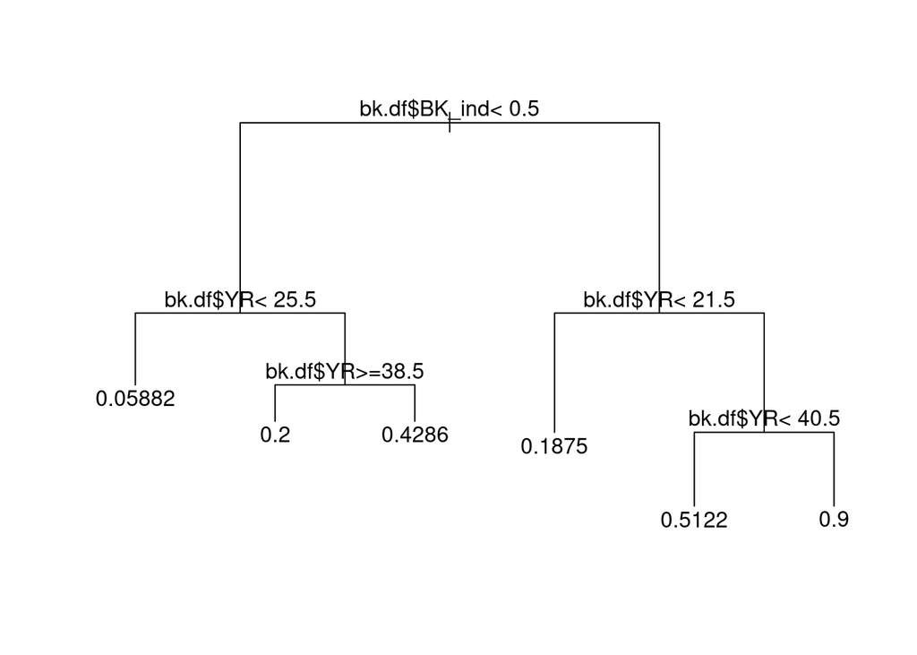

```r
library(rpart)
bk.rt <- rpart(bk.df$LC_ind ~ bk.df$BK_ind + bk.df$YR)
par(xpd = TRUE)
plot(bk.rt)
text(bk.rt, pretty=0)
```

```r
bk.rt
```

```
## n= 147
##
## node), split, n, deviance, yval
##       * denotes terminal node
##
##  1) root 147 32.666670 0.33333330
##    2) bk.df$BK_ind< 0.5 80 12.800000 0.20000000
##      4) bk.df$YR< 25.5 34  1.882353 0.05882353 *
##      5) bk.df$YR>=25.5 46  9.739130 0.30434780
##       10) bk.df$YR>=38.5 25  4.000000 0.20000000 *
##       11) bk.df$YR< 38.5 21  5.142857 0.42857140 *
##    3) bk.df$BK_ind>=0.5 67 16.746270 0.49253730
##      6) bk.df$YR< 21.5 16  2.437500 0.18750000 *
##      7) bk.df$YR>=21.5 51 12.352940 0.58823530
##       14) bk.df$YR< 40.5 41 10.243900 0.51219510 *
##       15) bk.df$YR>=40.5 10  0.900000 0.90000000 *
```

```r
printcp(bk.rt)
```

```
##
## Regression tree:
## rpart(formula = bk.df$LC_ind ~ bk.df$BK_ind + bk.df$YR)
##
## Variables actually used in tree construction:
## [1] bk.df$BK_ind bk.df$YR
##
## Root node error: 32.667/147 = 0.22222
##
## n= 147
##
##         CP nsplit rel error  xerror     xstd
## 1 0.095522      0   1.00000 1.01991 0.059784
## 2 0.059872      1   0.90448 1.03777 0.079900
## 3 0.037011      2   0.84461 0.96643 0.086257
## 4 0.036077      3   0.80759 0.96014 0.085379
## 5 0.018253      4   0.77152 0.93658 0.088225
## 6 0.010000      5   0.75326 0.98538 0.096229
```

```r
better.glm <- glm(bk.df$LC_ind ~ bk.df$BK_ind + bk.df$YR + I(bk.df$YR^2), family="binomial")
#str(bk.df)
summary(better.glm)
```

```
##
## Call:
## glm(formula = bk.df$LC_ind ~ bk.df$BK_ind + bk.df$YR + I(bk.df$YR^2),
##     family = "binomial")
##
## Deviance Residuals:
##     Min       1Q   Median       3Q      Max
## -1.4755  -0.8454  -0.4819   0.9544   2.2214
##
## Coefficients:
##                Estimate Std. Error z value Pr(>|z|)
## (Intercept)   -3.833264   1.011905  -3.788 0.000152 ***
## bk.df$BK_ind   1.454542   0.394154   3.690 0.000224 ***
## bk.df$YR       0.123289   0.070954   1.738 0.082282 .
## I(bk.df$YR^2) -0.001236   0.001261  -0.980 0.327052
## ---
## Signif. codes:  0 '***' 0.001 '**' 0.01 '*' 0.05 '.' 0.1 ' ' 1
##
## (Dispersion parameter for binomial family taken to be 1)
##
##     Null deviance: 187.14  on 146  degrees of freedom
## Residual deviance: 157.07  on 143  degrees of freedom
## AIC: 165.07
##
## Number of Fisher Scoring iterations: 5
```

```r
step(better.glm)
```

```
## Start:  AIC=165.07
## bk.df$LC_ind ~ bk.df$BK_ind + bk.df$YR + I(bk.df$YR^2)
##
##                 Df Deviance    AIC
## - I(bk.df$YR^2)  1   158.11 164.11
## <none>               157.07 165.07
## - bk.df$YR       1   160.97 166.97
## - bk.df$BK_ind   1   171.74 177.74
##
## Step:  AIC=164.11
## bk.df$LC_ind ~ bk.df$BK_ind + bk.df$YR
##
##                Df Deviance    AIC
## <none>              158.11 164.11
## - bk.df$YR      1   172.93 176.93
## - bk.df$BK_ind  1   173.17 177.17
```

```
##
## Call:  glm(formula = bk.df$LC_ind ~ bk.df$BK_ind + bk.df$YR, family = "binomial")
##
## Coefficients:
##  (Intercept)  bk.df$BK_ind      bk.df$YR
##     -3.18016       1.47555       0.05825
##
## Degrees of Freedom: 146 Total (i.e. Null);  144 Residual
## Null Deviance:       187.1
## Residual Deviance: 158.1     AIC: 164.1
```

```r
#creating table to see how many have lung cancer and are bird keepers with new model (odds ratio)
exp(fitMain.glm$coefficients[-1])
```

```
## bk.df$BK_ind     bk.df$YR
##     4.373447     1.059980
```

This means that those who do have lung cancer are 4.37 times more likely to have a bird than those who do not have lung cancer.

```r
simple.glm <- glm(bk.df$LC_ind ~ bk.df$BK_ind, family = "binomial")
summary(simple.glm)
```

```
##
## Call:
## glm(formula = bk.df$LC_ind ~ bk.df$BK_ind, family = "binomial")
##
## Deviance Residuals:
##     Min       1Q   Median       3Q      Max
## -1.1648  -0.6681  -0.6681   1.1901   1.7941
##
## Coefficients:
##              Estimate Std. Error z value Pr(>|z|)
## (Intercept)   -1.3863     0.2795  -4.960 7.06e-07 ***
## bk.df$BK_ind   1.3564     0.3713   3.654 0.000259 ***
## ---
## Signif. codes:  0 '***' 0.001 '**' 0.01 '*' 0.05 '.' 0.1 ' ' 1
##
## (Dispersion parameter for binomial family taken to be 1)
##
##     Null deviance: 187.14  on 146  degrees of freedom
## Residual deviance: 172.93  on 145  degrees of freedom
## AIC: 176.93
##
## Number of Fisher Scoring iterations: 4
```

```r
# Confidence interval for crude OR
exp(confint(simple.glm, level = .95))
```

```
##                 2.5 %    97.5 %
## (Intercept)  0.139705 0.4211127
## bk.df$BK_ind 1.901713 8.1988411
```

```r
# Confidence interval for adjusted OR
exp(confint(fitMain.glm, level = .95))
```

```
##                   2.5 %    97.5 %
## (Intercept)  0.01063132 0.1311953
## bk.df$BK_ind 2.05076095 9.7481749
## bk.df$YR     1.02757209 1.0982798
```